# Лабораторная работа №16

Администрирование сетевых подсистем

Иванов Сергей Владимирович, НПИбд-01-23

Российский университет дружбы народов, Москва, Россия

07 декабря 2025

# Цель работы

Получить навыки работы с программным средством Fail2ban для обеспечения базовой защиты от атак типа «brute force».

# Задание

1. Установите и настройте Fail2ban для отслеживания работы установленных на сервере служб
2. Проверьте работу Fail2ban посредством попыток несанкционированного доступа с клиента на сервер через SSH
3. Напишите скрипт для Vagrant, фиксирующий действия по установке и настройке Fail2ban

# Выполнение лабораторной работы

## Защита с помощью Fail2ban

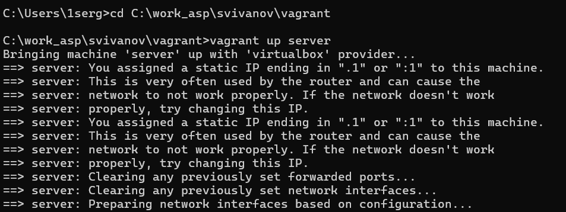

Запуск Server

## Защита с помощью Fail2ban

На сервере установим fail2ban

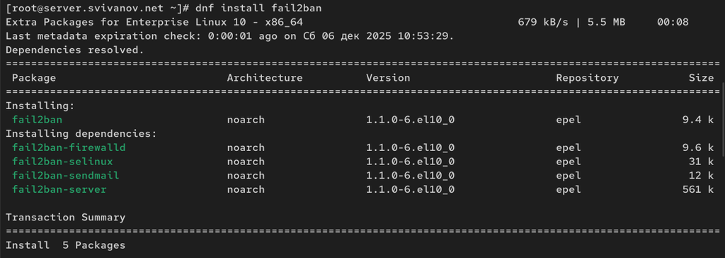

Установка fail2ban

## Защита с помощью Fail2ban

Запустим сервер fail2ban:

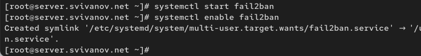

Запуск fail2ban

## Защита с помощью Fail2ban

В дополнительном терминале запустим просмотр журнала событий fail2ban:

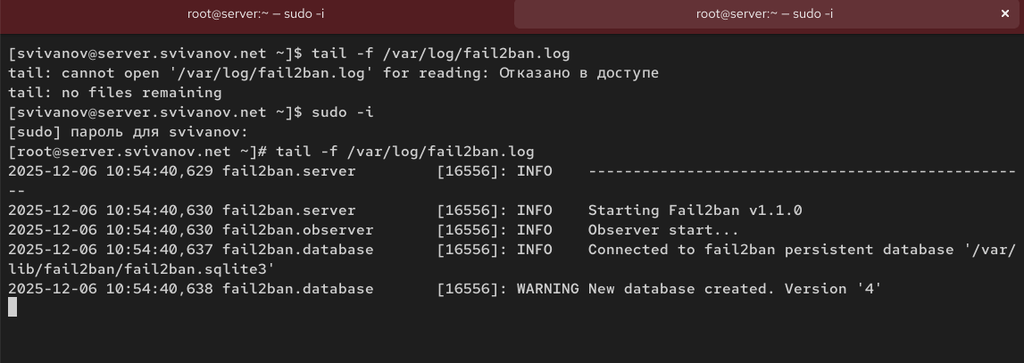

Запуск журнала событий

## Защита с помощью Fail2ban

Создадим файл с конфигурацией. Зададим время блокирования на 1 час и включим защиту SSH:

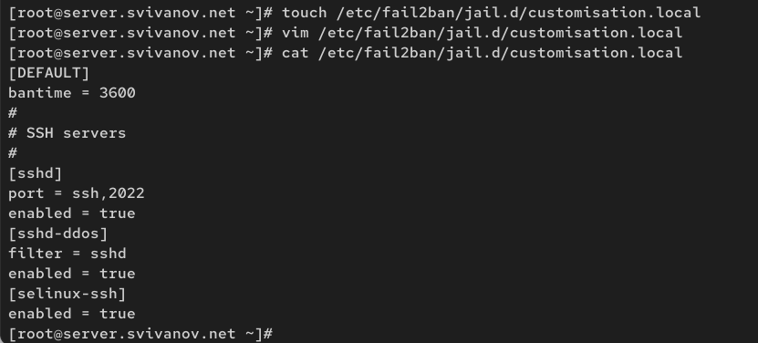

Создание конфигурации

## Защита с помощью Fail2ban

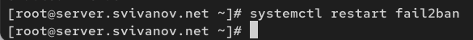

Перезапуск fail2ban

## Защита с помощью Fail2ban

Посмотрим журнал событий:

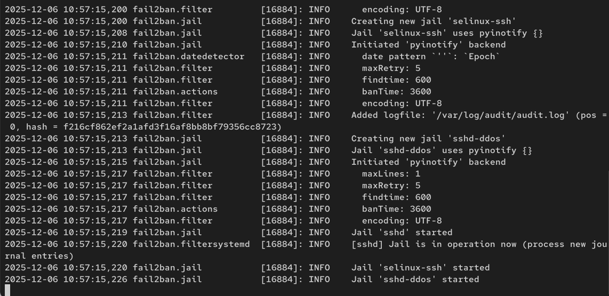

Просмотр журнала событий

## Защита с помощью Fail2ban

Включим защиту HTTP

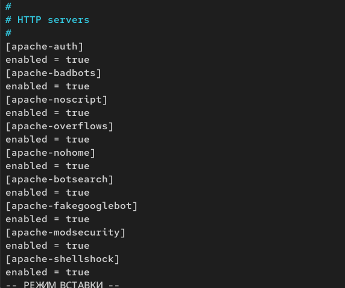

Редактирование конф. файла

## Защита с помощью Fail2ban

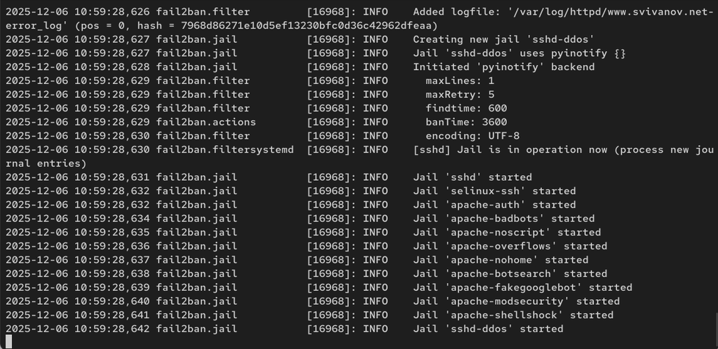

Перезапуск службы и просмотр журнала

## Защита с помощью Fail2ban

Включим защиту почты

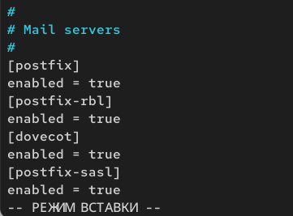

Редактирование конф. файла

## Защита с помощью Fail2ban

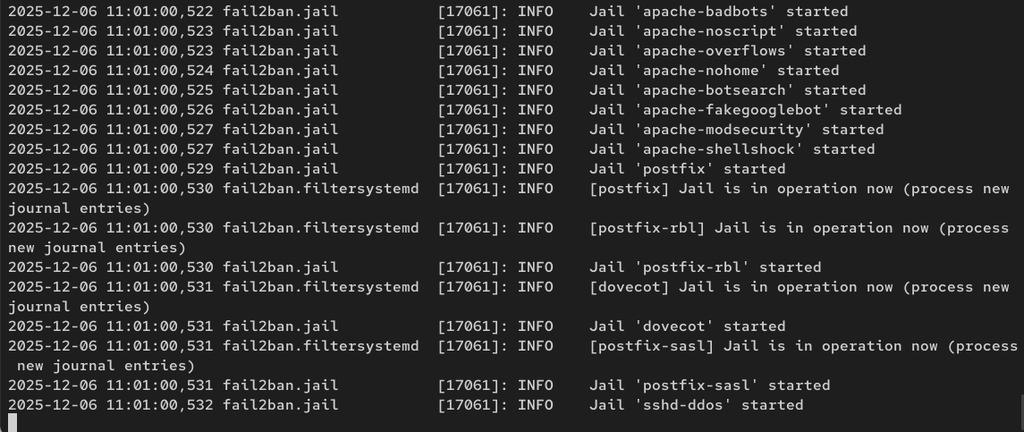

Перезапуск службы и просмотр журнала

## Проверка работы Fail2ban

На сервере посмотрим статус fail2ban

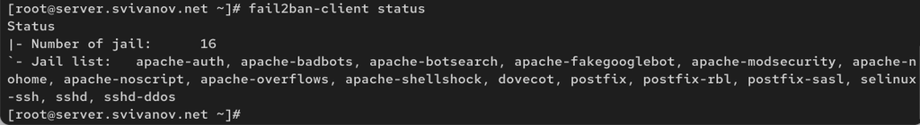

Просмотр статуса службы

## Проверка работы Fail2ban

Посмотрим статус защиты SSH в fail2ban

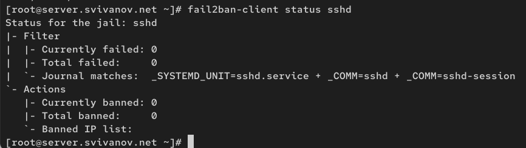

Просмотр статуса защиты SSH

## Проверка работы Fail2ban

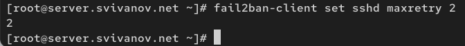

Установка макс. кол-ва ошибок

## Проверка работы Fail2ban

Запускаю виртуальную машину Client

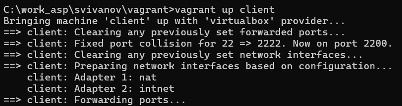

Запуск Client

## Проверка работы Fail2ban

С клиента попытаемся зайти по SSH на сервер с неправильным паролем.

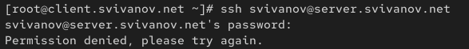

Попытка зайти по ssh с клиента

## Проверка работы Fail2ban

На сервере посмотрим статус защиты SSH

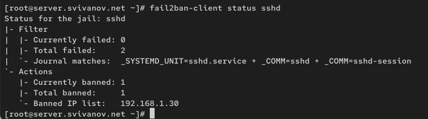

Блокировка адреса клиаента

## Проверка работы Fail2ban

Разблокируем IP-адрес клиента:

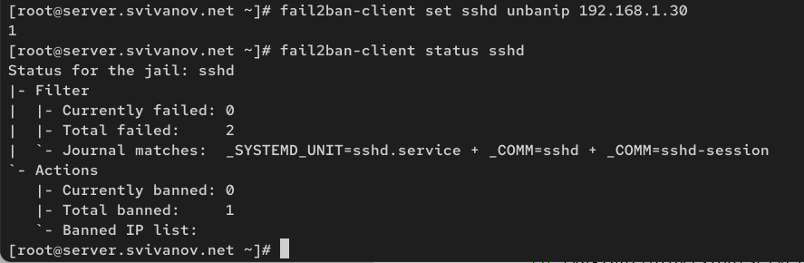

Разблокировка клиента

## Проверка работы Fail2ban

Внесем изменение в конфигурационный файл, добавив игнорирование адреса клиента

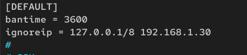

Редактирование конф. файла

## Проверка работы Fail2ban

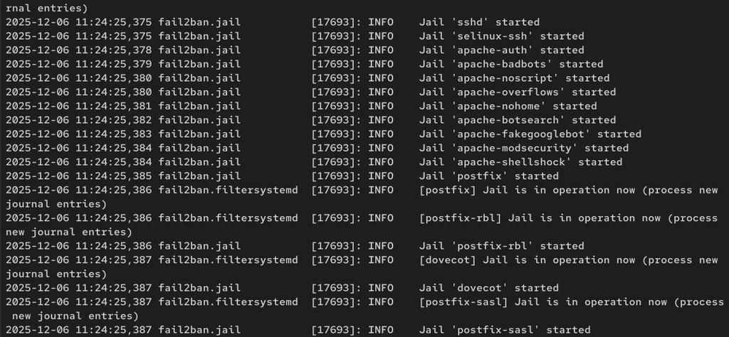

Перезапуск службы и просмотр журнала

## Проверка работы Fail2ban

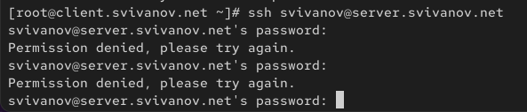

Попытка входа

## Проверка работы Fail2ban

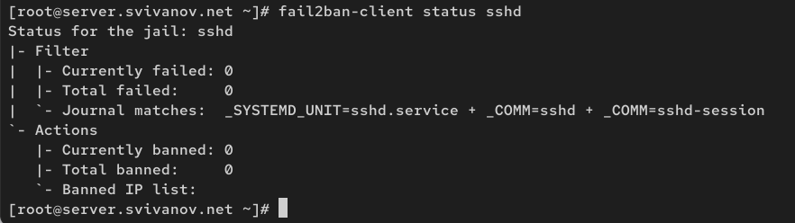

Статус защиты

## Внесение изменений в настройки внутреннего окружения виртуальных машин

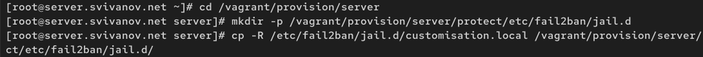

Создание директорий и копирование конф. файлов

## Внесение изменений в настройки внутреннего окружения виртуальных машин

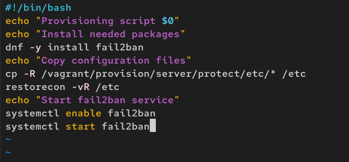

Создание скрипта

## Внесение изменений в настройки внутреннего окружения виртуальных машин

Для отработки скрипта во время загрузки машины server в файле Vagrantfile необходимо добавить:

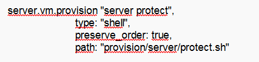

Редактирование Vagrantfile

## Вывод

В ходе выполнения лабораторной работы мы получили навыки работы с программным средством Fail2ban для обеспечения базовой защиты от атак типа «brute force».